# Exploratory Data Analysis of Attrition by DDSAnalytics Company

Eny Ntuk

2022-12-04

## Objective

### This study is to analyze and identify the top 3 factors that contribute to turnover (attrition) in this talent management company, DDS Analytics. Make recommendations for HR department to help improve talent management in the company and show any job role specific trends that may exist in the data sets. Build a model to prediction “Attrition” and “Monthly Income”. Develop an Shiny App to visualize some of the relationships or lack thereof from the analysis.

YouTube Presentation:https://youtu.be/XHbbq70i7nY GITHub Repository: https://github.com/enyntuk/CaseStudy2DDS.git ShinyApp: https://wgzgum-eny-ntuk.shinyapps.io/CaseStudy2_Project/ Jekyll: https://github.com/enyntuk/EnyNtuk.github.io.git

```r
library(tidyverse)
library(janitor)
library(arules)
library(aod)
library(AICcmodavg)
library(dplyr)
library(class)
library(caret)
library(e1071)
library(olsrr)
library(leaps)
library(tibble)
library(modeldata)
library(shiny)

CStudy2_data <- read.csv("CaseStudy2-data.csv", header=TRUE)
head(CStudy2_data)
```

```
##   ID Age Attrition    BusinessTravel DailyRate             Department
## 1  1  32        No     Travel_Rarely       117                  Sales
## 2  2  40        No     Travel_Rarely      1308 Research & Development
## 3  3  35        No Travel_Frequently       200 Research & Development
## 4  4  32        No     Travel_Rarely       801                  Sales
## 5  5  24        No Travel_Frequently       567 Research & Development
## 6  6  27        No Travel_Frequently       294 Research & Development
##   DistanceFromHome Education   EducationField EmployeeCount EmployeeNumber
## 1               13         4    Life Sciences             1            859
## 2               14         3          Medical             1           1128
## 3               18         2    Life Sciences             1           1412
## 4                1         4        Marketing             1           2016
## 5                2         1 Technical Degree             1           1646
## 6               10         2    Life Sciences             1            733
##   EnvironmentSatisfaction Gender HourlyRate JobInvolvement JobLevel
```

[output cut: 41 more lines]

### Cleaning Data:

#### - remove columns that have no practical association with attrition and monthly income

#### - change attrition values to 0 and 1

#### - recode factor levels with snake case names

```r
CStudy2_data <- CStudy2_data %>% janitor::clean_names()
CStudy2_data$employee_count <- NULL
CStudy2_data$over18 <- NULL
CStudy2_data$standard_hours <- NULL
CStudy2_data$id <- NULL
CStudy2_data$employee_number <- NULL
CStudy2_data <- CStudy2_data %>% mutate(attrition = if_else(attrition == "No", 0, 1))
head(CStudy2_data)
```

```
##   age attrition   business_travel daily_rate             department
## 1  32         0     Travel_Rarely        117                  Sales
## 2  40         0     Travel_Rarely       1308 Research & Development
## 3  35         0 Travel_Frequently        200 Research & Development
## 4  32         0     Travel_Rarely        801                  Sales
## 5  24         0 Travel_Frequently        567 Research & Development
## 6  27         0 Travel_Frequently        294 Research & Development
##   distance_from_home education  education_field environment_satisfaction gender
## 1                 13         4    Life Sciences                        2   Male
## 2                 14         3          Medical                        3   Male
## 3                 18         2    Life Sciences                        3   Male
## 4                  1         4        Marketing                        3 Female
## 5                  2         1 Technical Degree                        1 Female
## 6                 10         2    Life Sciences                        4   Male
##   hourly_rate job_involvement job_level               job_role job_satisfaction
```

[output cut: 41 more lines]

```r
CStudy2_data$department <- as.factor(CStudy2_data$department)
CStudy2_data$education_field <- as.factor(CStudy2_data$education_field)
CStudy2_data$gender <- as.factor(CStudy2_data$gender)
CStudy2_data$marital_status <- as.factor(CStudy2_data$marital_status)
CStudy2_data$over_time <- as.factor(CStudy2_data$over_time)

levels(CStudy2_data$education_field)
```

```
## [1] "Human Resources"  "Life Sciences"    "Marketing"        "Medical"
## [5] "Other"            "Technical Degree"
```

```r
CStudy2_data$education_field <- recode_factor(CStudy2_data$education_field,"Human Resources" = 'human_resources',"Marketing" = 'marketing', "Medical" = 'medical',"Other" = 'other', "Technical Degree" = 'technical_degree', "Life Sciences" = 'life_sciences')
levels(CStudy2_data$education_field)
```

```
## [1] "human_resources"  "marketing"        "medical"          "other"
## [5] "technical_degree" "life_sciences"
```

```r
levels(CStudy2_data$department)
```

```
## [1] "Human Resources"        "Research & Development" "Sales"
```

```r
CStudy2_data$department <- recode_factor(CStudy2_data$department, "Human Resources" = 'human_resources', "Research & Development" = 'research_and_development', "Sales" = 'sales')
levels(CStudy2_data$job_role)
```

[output not shown]

```r
CStudy2_data$job_role <- recode_factor(CStudy2_data$job_role, "Healthcare Representative" = 'healthcare_representative', "Human Resources" = 'human_resources', "Laboratory Technician" = 'laboratory_technician', "Manager" = 'manager', "Manufacturing Director" = 'manufacturing_director', "Research Director" = 'research_director', "Research Scientist" = 'research_scientist', "Sales Executive" = 'sales_executive', "Sales Representative" = 'sales_representative')
```

### Exploratory Data Analysis

#### - Create graphs for each variable against attrition

#### - Divide into “internal” and “external” variables

#### - Set 30% attrition rate for a level of a variable as significant

```r
### External, not significant

total <- CStudy2_data %>% select(education_field, attrition) %>%
  group_by(education_field) %>% arrange(education_field) %>%
  dplyr::count(education_field) %>% as.data.frame()

yes_count <- CStudy2_data %>% select(education_field, attrition) %>%
  group_by(education_field) %>% arrange(education_field) %>%
  filter(attrition == "1") %>% dplyr::count(education_field) %>%
  dplyr::rename(yes = n) %>% as.data.frame()

head(yes_count)
```

```
##    education_field yes
## 1  human_resources   4
## 2        marketing  20
## 3          medical  37
## 4            other   9
## 5 technical_degree  17
## 6    life_sciences  53
```

```r
head(total)
```

```
##    education_field   n
## 1  human_resources  15
## 2        marketing 100
## 3          medical 270
## 4            other  52
## 5 technical_degree  75
## 6    life_sciences 358
```

```r
join <- full_join(total, yes_count, by = "education_field") %>% mutate(perc = (yes/n)*100)
join$education_field <- as.factor(join$education_field)
head(join)
```

```
##    education_field   n yes     perc
## 1  human_resources  15   4 26.66667
## 2        marketing 100  20 20.00000
## 3          medical 270  37 13.70370
## 4            other  52   9 17.30769
## 5 technical_degree  75  17 22.66667
## 6    life_sciences 358  53 14.80447
```

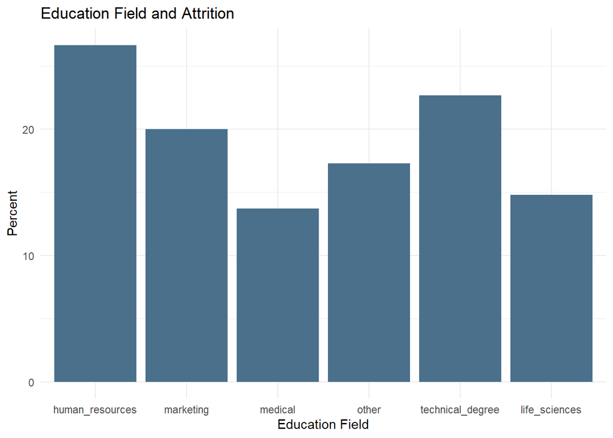

```r
join %>% ggplot(aes(x = education_field, y = perc)) + geom_bar(stat = 'identity', fill = 'skyblue4') + theme_minimal() + ggtitle("Education Field and Attrition") +  labs(x = "Education Field", y = "Percent")
```

```r
### external, significant
total <- CStudy2_data %>% mutate(age = discretize(age, method = 'interval', breaks = 6)) %>% select(age, attrition) %>% group_by(age) %>% arrange(age) %>% dplyr::count(age) %>% as.data.frame()

yes_count <- CStudy2_data %>% mutate(age = discretize(age, method = 'interval', breaks = 6)) %>% select(age, attrition) %>% group_by(age) %>% arrange(age) %>% filter(attrition == "1") %>% dplyr::count(age) %>% dplyr::rename(yes = n) %>% as.data.frame()

head(total)
```

```
##       age   n
## 1 [18,25)  55
## 2 [25,32) 206
## 3 [32,39) 287
## 4 [39,46) 165
## 5 [46,53) 103
## 6 [53,60]  54
```

```r
head(yes_count)
```

```
##       age yes
## 1 [18,25)  20
## 2 [25,32)  47
## 3 [32,39)  36
## 4 [39,46)  17
## 5 [46,53)  13
## 6 [53,60]   7
```

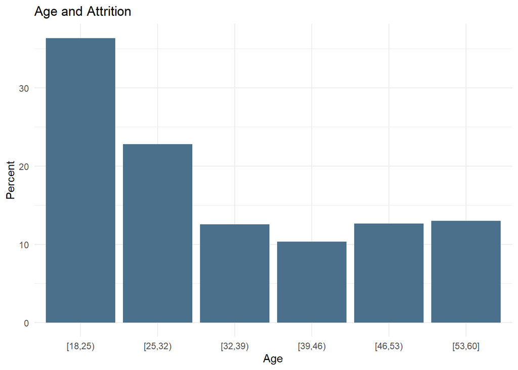

```r
join <- full_join(total, yes_count, by = "age")
join <- join %>% mutate(perc = (yes/n)*100)
join %>% ggplot(aes(x = age, y = perc)) + geom_bar(stat = 'identity', fill = 'skyblue4') + theme_minimal() + ggtitle("Age and Attrition") + labs(x = "Age", y = "Percent")
```

```r
### internal, not significant
total <- CStudy2_data %>% select(attrition, business_travel) %>% group_by(business_travel) %>% arrange(business_travel) %>% count(business_travel) %>% as.data.frame()

yes_count <- CStudy2_data %>% select(business_travel, attrition) %>% group_by(business_travel) %>% arrange(business_travel) %>% filter(attrition == "1") %>% count(business_travel) %>% rename(yes = n) %>% as.data.frame()

head(total)
```

```
##     business_travel   n
## 1        Non-Travel  94
## 2 Travel_Frequently 158
## 3     Travel_Rarely 618
```

```r
yes_count
```

```
##     business_travel yes
## 1        Non-Travel  11
## 2 Travel_Frequently  35
## 3     Travel_Rarely  94
```

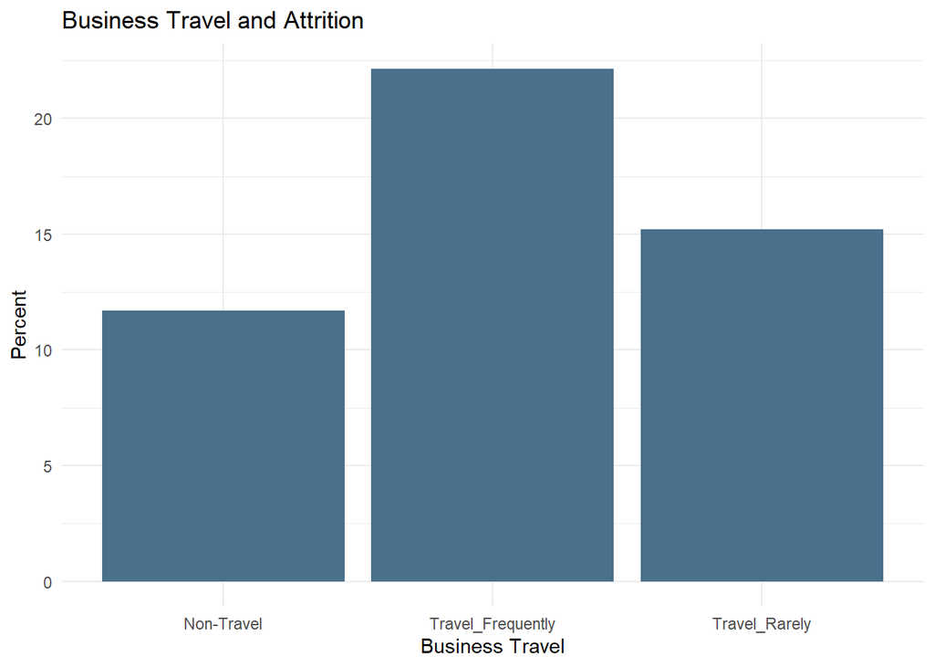

```r
join <- full_join(total, yes_count, by = "business_travel")
join <- join %>% mutate(perc = (yes/n)*100)
join %>% ggplot(aes(x = business_travel, y = perc)) + geom_bar(stat = 'identity', fill = 'skyblue4') + theme_minimal() + ggtitle("Business Travel and Attrition") + labs(x = "Business Travel", y = "Percent")
```

```r
### internal, not significant
total <- CStudy2_data %>% select(attrition, department) %>% group_by(department) %>% arrange(department) %>% count(department) %>% as.data.frame()

yes_count <- CStudy2_data %>% select(department, attrition) %>% group_by(department) %>% arrange(department) %>% filter(attrition == "1") %>% count(department) %>% rename(yes = n) %>% as.data.frame()

head(total)
```

```
##                 department   n
## 1          human_resources  35
## 2 research_and_development 562
## 3                    sales 273
```

```r
yes_count
```

```
##                 department yes
## 1          human_resources   6
## 2 research_and_development  75
## 3                    sales  59
```

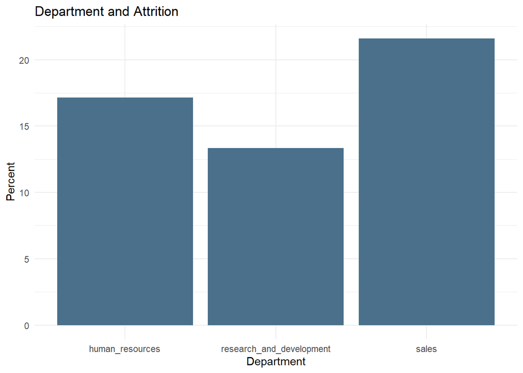

```r
join <- full_join(total, yes_count, by = "department")
join <- join %>% mutate(perc = (yes/n)*100)
join %>% ggplot(aes(x = department, y = perc)) + geom_bar(stat = 'identity', fill = 'skyblue4') + theme_minimal() + ggtitle("Department and Attrition") + labs(x = "Department", y = "Percent")
```

```r
### external, significant
total <- CStudy2_data %>% select(attrition, distance_from_home) %>% mutate(distance_from_home = discretize(distance_from_home, method = 'interval', breaks = 6)) %>% group_by(distance_from_home) %>% arrange(distance_from_home) %>% dplyr::count(distance_from_home) %>% as.data.frame()

yes_count <- CStudy2_data %>% select(distance_from_home, attrition) %>% mutate(distance_from_home = discretize(distance_from_home, method = 'interval', breaks = 6)) %>% filter(attrition == "1") %>% group_by(distance_from_home) %>% arrange(distance_from_home) %>% dplyr::count(distance_from_home) %>% dplyr::rename(yes = n) %>% as.data.frame()

head(total)
```

```
##   distance_from_home   n
## 1           [1,5.67) 367
## 2        [5.67,10.3) 233
## 3          [10.3,15)  53
## 4          [15,19.7)  78
## 5        [19.7,24.3)  74
## 6          [24.3,29]  65
```

```r
head(yes_count)
```

```
##   distance_from_home yes
## 1           [1,5.67)  52
## 2        [5.67,10.3)  30
## 3          [10.3,15)  12
## 4          [15,19.7)  13
## 5        [19.7,24.3)  24
## 6          [24.3,29]   9
```

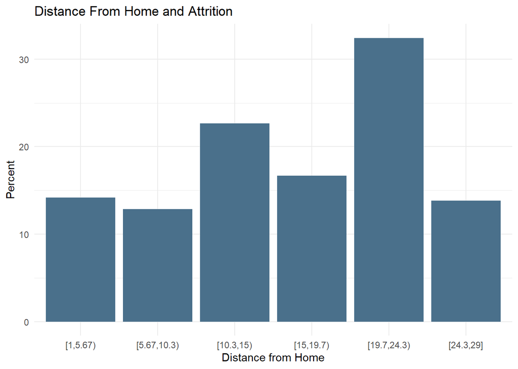

```r
join <- full_join(total, yes_count, by = "distance_from_home")
join <- join %>% mutate(perc = (yes/n)*100)
join %>% ggplot(aes(x = distance_from_home, y = perc)) + geom_bar(stat = 'identity', fill = 'skyblue4') + theme_minimal() + ggtitle("Distance From Home and Attrition") + labs(x = "Distance from Home", y = "Percent")
```

```r
### external, not significant
total <- CStudy2_data %>% select(attrition, education) %>% group_by(education) %>% arrange(education) %>% count(education) %>% as.data.frame()

yes_count <- CStudy2_data %>% select(education, attrition) %>% group_by(education) %>% arrange(education) %>% filter(attrition == "1") %>% count(education) %>% rename(yes = n) %>% as.data.frame()

head(total)
```

```
##   education   n
## 1         1  98
## 2         2 182
## 3         3 324
## 4         4 240
## 5         5  26
```

```r
yes_count
```

```
##   education yes
## 1         1  18
## 2         2  32
## 3         3  55
## 4         4  32
## 5         5   3
```

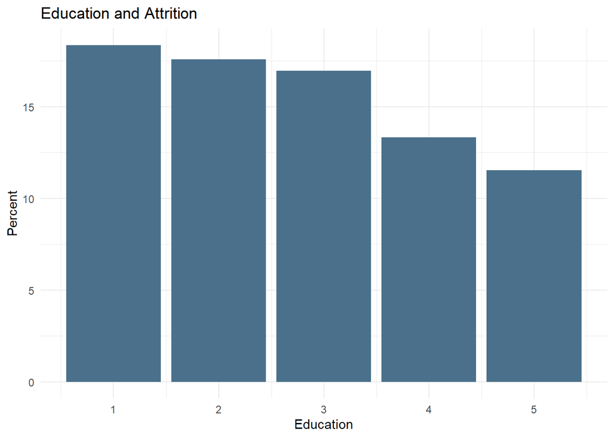

```r
join <- full_join(total, yes_count, by = "education")
join <- join %>% mutate(perc = (yes/n)*100)
join %>% ggplot(aes(x = education, y = perc)) + geom_bar(stat = 'identity', fill = 'skyblue4') + theme_minimal() + ggtitle("Education and Attrition") + labs(x = "Education", y = "Percent")
```

```r
### internal, not significant
total <- CStudy2_data %>% select(attrition, environment_satisfaction) %>% group_by(environment_satisfaction) %>% arrange(environment_satisfaction) %>% count(environment_satisfaction) %>% as.data.frame()

yes_count <- CStudy2_data %>% select(environment_satisfaction, attrition) %>% group_by(environment_satisfaction) %>% arrange(environment_satisfaction) %>% filter(attrition == "1") %>% count(environment_satisfaction) %>% rename(yes = n) %>% as.data.frame()

head(total)
```

```
##   environment_satisfaction   n
## 1                        1 172
## 2                        2 178
## 3                        3 258
## 4                        4 262
```

```r
yes_count
```

```
##   environment_satisfaction yes
## 1                        1  42
## 2                        2  24
## 3                        3  35
## 4                        4  39
```

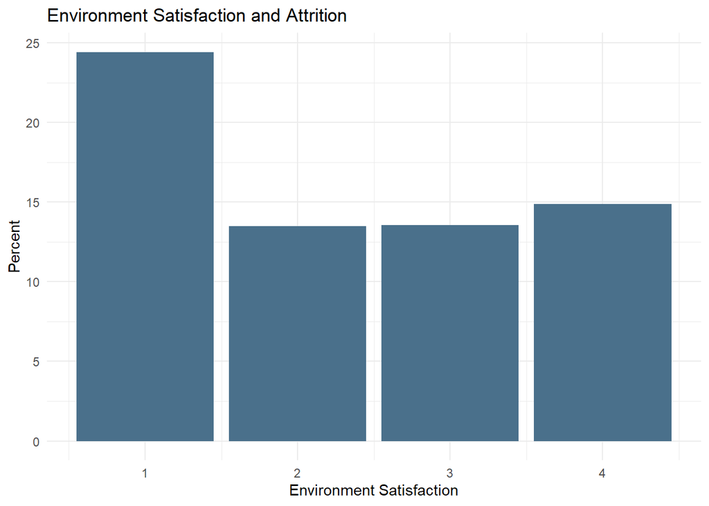

```r
join <- full_join(total, yes_count, by = "environment_satisfaction")
join <- join %>% mutate(perc = (yes/n)*100)
join %>% ggplot(aes(x = environment_satisfaction, y = perc)) + geom_bar(stat = 'identity', fill = 'skyblue4') + theme_minimal() + ggtitle("Environment Satisfaction and Attrition") + labs(x = "Environment Satisfaction", y = "Percent")
```

```r
### external, not significant
total <- CStudy2_data %>% select(attrition, gender) %>% group_by(gender) %>% arrange(gender) %>% count(gender) %>% as.data.frame()

yes_count <- CStudy2_data %>% select(gender, attrition) %>% group_by(gender) %>% arrange(gender) %>% filter(attrition == "1") %>% count(gender) %>% rename(yes = n) %>% as.data.frame()

head(total)
```

```
##   gender   n
## 1 Female 354
## 2   Male 516
```

```r
yes_count
```

```
##   gender yes
## 1 Female  53
## 2   Male  87
```

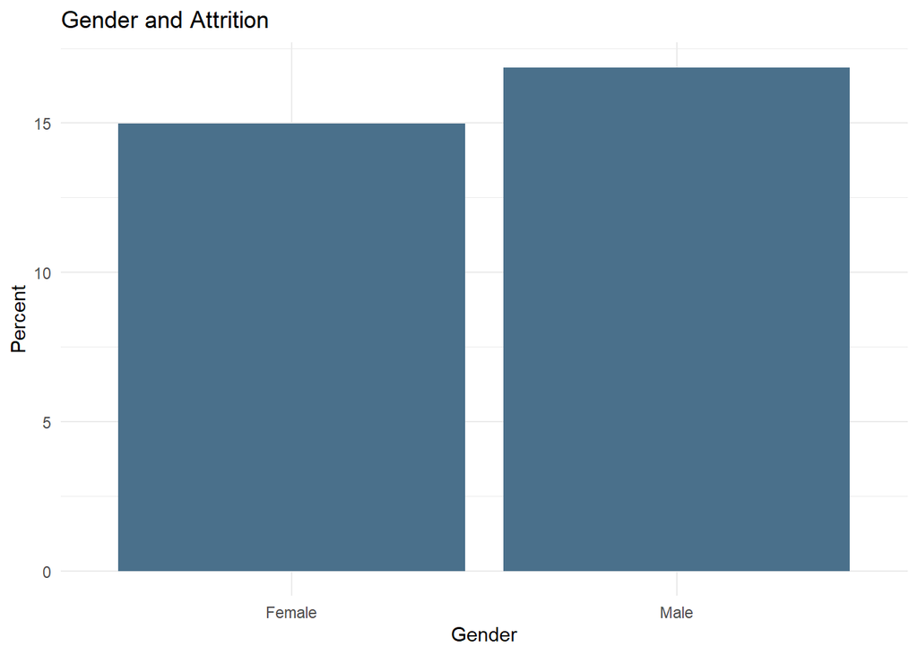

```r
join <- full_join(total, yes_count, by = "gender")
join <- join %>% mutate(perc = (yes/n)*100)
join %>% ggplot(aes(x = gender, y = perc)) + geom_bar(stat = 'identity', fill = 'skyblue4') + theme_minimal() + ggtitle("Gender and Attrition") + labs(x = "Gender", y = "Percent")
```

```r
### internal, not significant
total <- CStudy2_data %>% select(attrition, hourly_rate) %>% mutate(hourly_rate = discretize(hourly_rate, method = 'interval', breaks = 10)) %>% group_by(hourly_rate) %>% arrange(hourly_rate) %>% count(hourly_rate) %>% as.data.frame()

yes_count <- CStudy2_data %>% select(hourly_rate, attrition) %>% mutate(hourly_rate = discretize(hourly_rate, method = 'interval', breaks = 10)) %>% filter(attrition == "1") %>% group_by(hourly_rate) %>% arrange(hourly_rate) %>% count(hourly_rate) %>% rename(yes = n) %>% as.data.frame()

head(total)
```

```
##   hourly_rate   n
## 1     [30,37)  69
## 2     [37,44)  87
## 3     [44,51)  88
## 4     [51,58) 102
## 5     [58,65)  79
## 6     [65,72)  73
```

```r
yes_count
```

```
##    hourly_rate yes
## 1      [30,37)  10
## 2      [37,44)  10
## 3      [44,51)  14
## 4      [51,58)  15
## 5      [58,65)  11
## 6      [65,72)  20
## 7      [72,79)  13
## 8      [79,86)  18
## 9      [86,93)  10
## 10    [93,100]  19
```

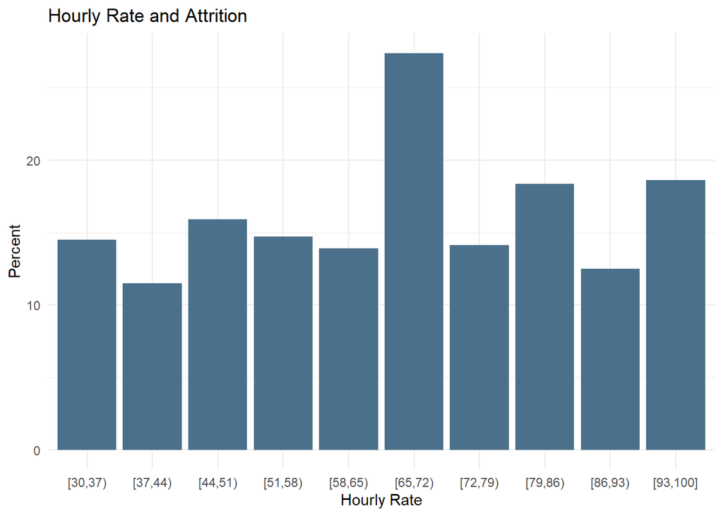

```r
join <- full_join(total, yes_count, by = "hourly_rate")
join <- join %>% mutate(perc = (yes/n)*100)
join %>% ggplot(aes(x = hourly_rate, y = perc)) + geom_bar(stat = 'identity', fill = 'skyblue4') + theme_minimal() + ggtitle("Hourly Rate and Attrition") + labs(x = 'Hourly Rate', y  = "Percent")
```

```r
### internal, super significant
total <- CStudy2_data %>% select(attrition, job_involvement) %>% group_by(job_involvement) %>% arrange(job_involvement) %>% count(job_involvement) %>% as.data.frame()

yes_count <- CStudy2_data %>% select(job_involvement, attrition) %>% group_by(job_involvement) %>% arrange(job_involvement) %>% filter(attrition == "1") %>% count(job_involvement) %>% rename(yes = n) %>% as.data.frame()

head(total)
```

```
##   job_involvement   n
## 1               1  47
## 2               2 228
## 3               3 514
## 4               4  81
```

```r
yes_count
```

```
##   job_involvement yes
## 1               1  22
## 2               2  44
## 3               3  67
## 4               4   7
```

```r
join <- full_join(total, yes_count, by = "job_involvement")
join <- join %>% mutate(perc = (yes/n)*100)
join
```

```
##   job_involvement   n yes      perc
## 1               1  47  22 46.808511
## 2               2 228  44 19.298246
## 3               3 514  67 13.035019
## 4               4  81   7  8.641975
```

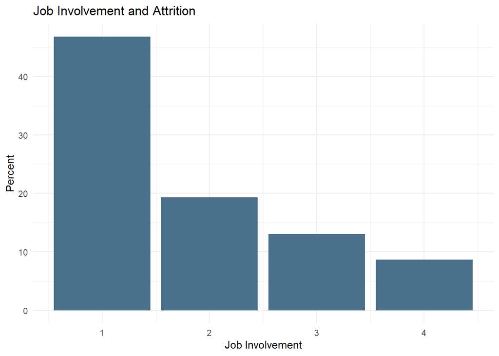

```r
join %>% ggplot(aes(x = job_involvement, y = perc)) + geom_bar(stat = 'identity', fill = 'skyblue4') + theme_minimal() + ggtitle("Job Involvement and Attrition") + labs(x = "Job Involvement", y = "Percent")
```

```r
### internal, not significant
total <- CStudy2_data %>% select(attrition, job_level) %>% group_by(job_level) %>% arrange(job_level) %>% count(job_level) %>% as.data.frame()

yes_count <- CStudy2_data %>% select(job_level, attrition) %>% group_by(job_level) %>% arrange(job_level) %>% filter(attrition == "1") %>% count(job_level) %>% rename(yes = n) %>% as.data.frame()

head(total)
```

```
##   job_level   n
## 1         1 329
## 2         2 312
## 3         3 132
## 4         4  60
## 5         5  37
```

```r
yes_count
```

```
##   job_level yes
## 1         1  86
## 2         2  30
## 3         3  17
## 4         4   3
## 5         5   4
```

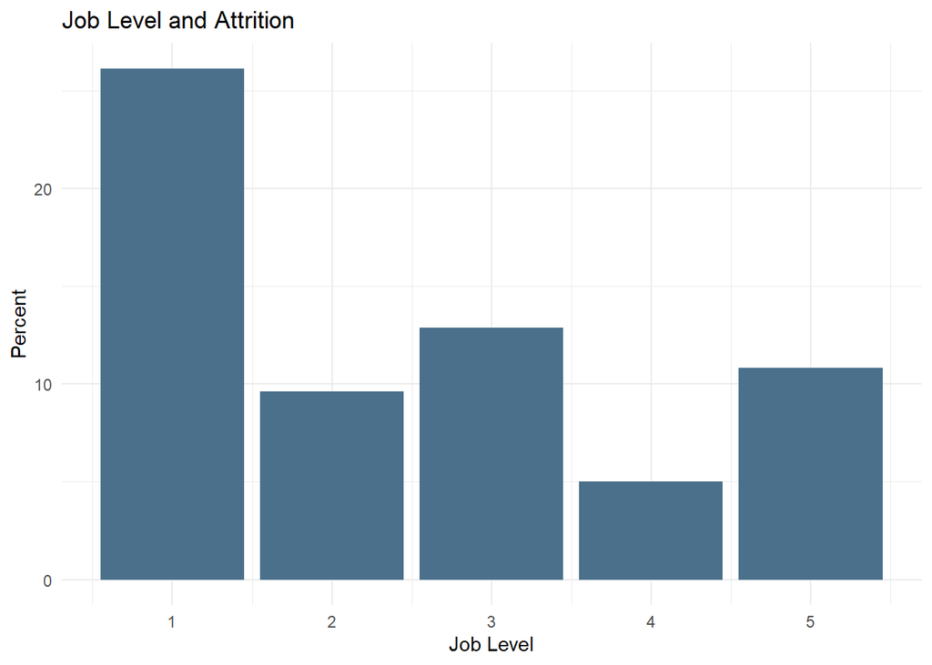

```r
join <- full_join(total, yes_count, by = "job_level")
join <- join %>% mutate(perc = (yes/n)*100)
join %>% ggplot(aes(x = job_level, y = perc)) + geom_bar(stat = 'identity', fill = 'skyblue4') + theme_minimal() + ggtitle("Job Level and Attrition") + labs(x = "Job Level", y = "Percent")
```

```r
### internal, worth investigating
total <- CStudy2_data %>% select(attrition, job_role) %>% group_by(job_role) %>% arrange(job_role) %>% count(job_role) %>% as.data.frame()

yes_count <- CStudy2_data %>% select(job_role, attrition) %>% group_by(job_role) %>% arrange(job_role) %>% filter(attrition == "1") %>% count(job_role) %>% rename(yes = n) %>% as.data.frame()

head(total, 10)
```

```
##                    job_role   n
## 1 healthcare_representative  76
## 2           human_resources  27
## 3     laboratory_technician 153
## 4                   manager  51
## 5    manufacturing_director  87
## 6         research_director  51
## 7        research_scientist 172
## 8           sales_executive 200
## 9      sales_representative  53
```

```r
yes_count
```

```
##                    job_role yes
## 1 healthcare_representative   8
## 2           human_resources   6
## 3     laboratory_technician  30
## 4                   manager   4
## 5    manufacturing_director   2
## 6         research_director   1
## 7        research_scientist  32
## 8           sales_executive  33
## 9      sales_representative  24
```

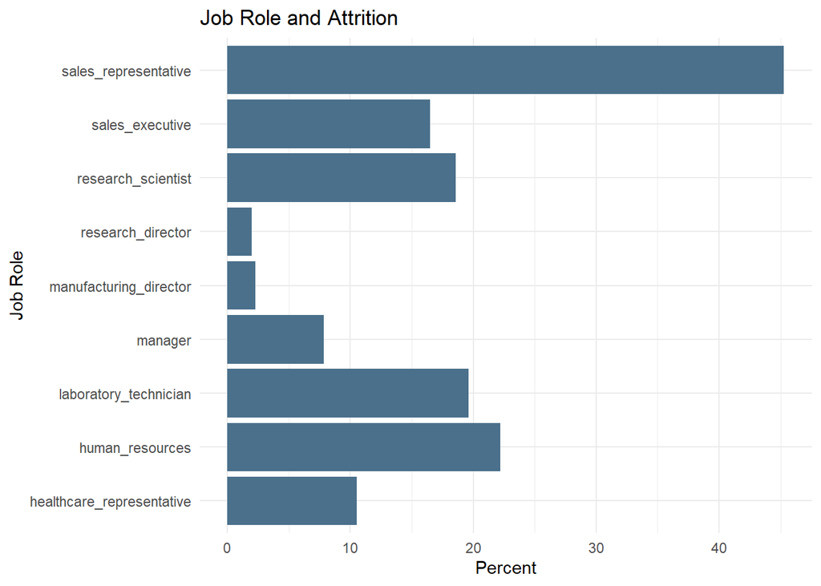

```r
join <- full_join(total, yes_count, by = "job_role")
join <- join %>% mutate(perc = (yes/n)*100)
join %>% ggplot(aes(x = job_role, y = perc)) + geom_bar(stat = 'identity', fill = 'skyblue4') + theme_minimal() + coord_flip() + ggtitle("Job Role and Attrition") + labs(x = "Job Role", y = "Percent")
```

```r
### internal, worth exploring
total <- CStudy2_data %>% select(attrition, job_satisfaction) %>% group_by(job_satisfaction) %>% arrange(job_satisfaction) %>% count(job_satisfaction) %>% as.data.frame()
yes_count <- CStudy2_data %>% select(job_satisfaction, attrition) %>% group_by(job_satisfaction) %>% arrange(job_satisfaction) %>% filter(attrition == "1") %>% count(job_satisfaction) %>% rename(yes = n) %>% as.data.frame()
head(total)
```

```
##   job_satisfaction   n
## 1                1 179
## 2                2 166
## 3                3 254
## 4                4 271
```

```r
yes_count
```

```
##   job_satisfaction yes
## 1                1  38
## 2                2  31
## 3                3  43
## 4                4  28
```

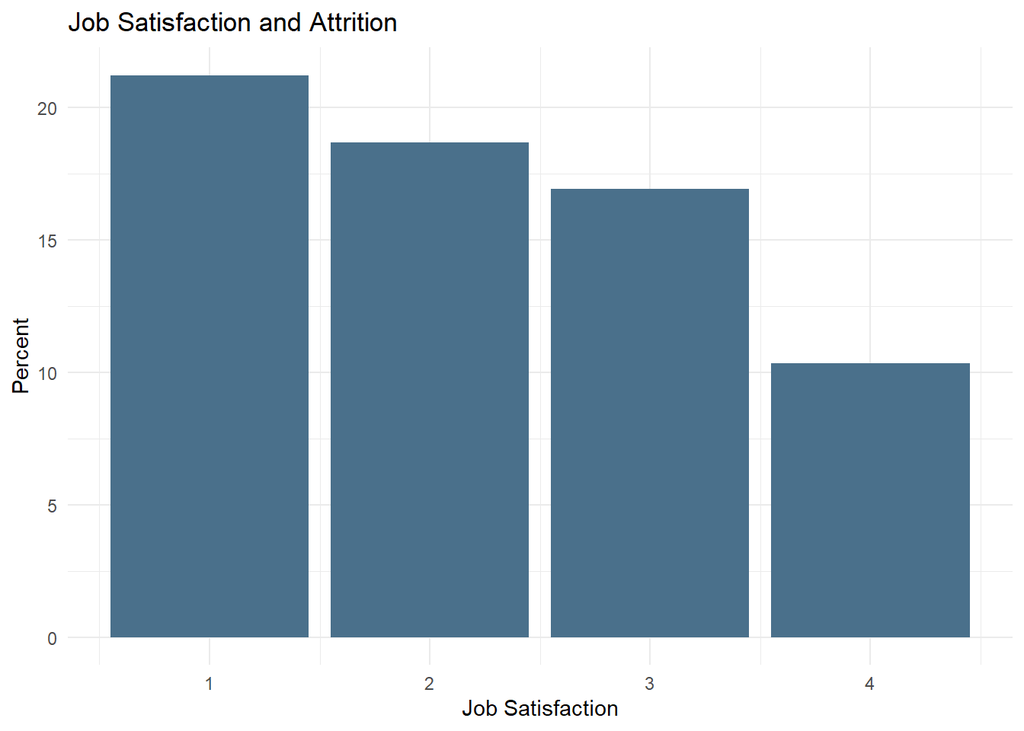

```r
join <- full_join(total, yes_count, by = "job_satisfaction")
join <- join %>% mutate(perc = (yes/n)*100)
join %>% ggplot(aes(x = job_satisfaction, y = perc)) + geom_bar(stat = 'identity', fill = 'skyblue4') + theme_minimal() + ggtitle("Job Satisfaction and Attrition") + labs(x = "Job Satisfaction", y = "Percent")
```

```r
### external, not significant
total <- CStudy2_data %>% select(attrition, marital_status) %>% group_by(marital_status) %>% arrange(marital_status) %>% count(marital_status) %>% as.data.frame()
yes_count <- CStudy2_data %>% select(marital_status, attrition) %>% group_by(marital_status) %>% arrange(marital_status) %>% filter(attrition == "1") %>% count(marital_status) %>% rename(yes = n) %>% as.data.frame()
head(total)
```

```
##   marital_status   n
## 1       Divorced 191
## 2        Married 410
## 3         Single 269
```

```r
yes_count
```

```
##   marital_status yes
## 1       Divorced  12
## 2        Married  58
## 3         Single  70
```

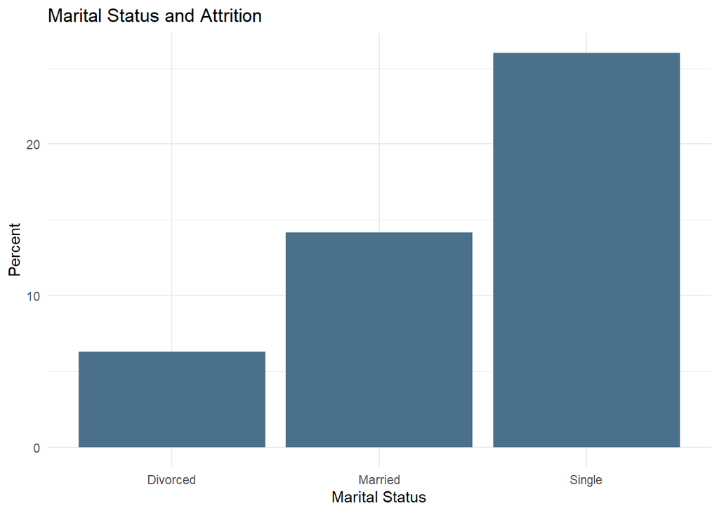

```r
join <- full_join(total, yes_count, by = "marital_status")
join <- join %>% mutate(perc = (yes/n)*100)
join %>% ggplot(aes(x = marital_status, y = perc)) + geom_bar(stat = 'identity', fill = 'skyblue4') + theme_minimal() + ggtitle("Marital Status and Attrition") + labs(x = "Marital Status", y = "Percent")
```

```r
### internal, significant
total <- CStudy2_data %>% select(attrition, monthly_income) %>%
  mutate(monthly_income = discretize(monthly_income, breaks = 6)) %>%
  group_by(monthly_income) %>% arrange(monthly_income) %>%
  count(monthly_income) %>% as.data.frame()
yes_count <- CStudy2_data %>% select(attrition, monthly_income) %>%
  mutate(monthly_income = discretize(monthly_income, breaks = 6)) %>% filter(attrition == "1") %>%
  group_by(monthly_income) %>% arrange(monthly_income) %>%
  count(monthly_income) %>% rename(yes = n) %>% as.data.frame()
yes_count
```

```
##        monthly_income yes
## 1 [1.08e+03,2.51e+03)  49
## 2 [2.51e+03,3.57e+03)  28
## 3 [3.57e+03,4.95e+03)  20
## 4 [4.95e+03,6.48e+03)  14
## 5 [6.48e+03,1.04e+04)  19
## 6    [1.04e+04,2e+04]  10
```

```r
join <- full_join(total, yes_count, by = "monthly_income")
join <- join %>% mutate(perc = (yes/n)*100)
join
```

```
##        monthly_income   n yes      perc
## 1 [1.08e+03,2.51e+03) 145  49 33.793103
## 2 [2.51e+03,3.57e+03) 145  28 19.310345
## 3 [3.57e+03,4.95e+03) 145  20 13.793103
## 4 [4.95e+03,6.48e+03) 145  14  9.655172
## 5 [6.48e+03,1.04e+04) 145  19 13.103448
## 6    [1.04e+04,2e+04] 145  10  6.896552
```

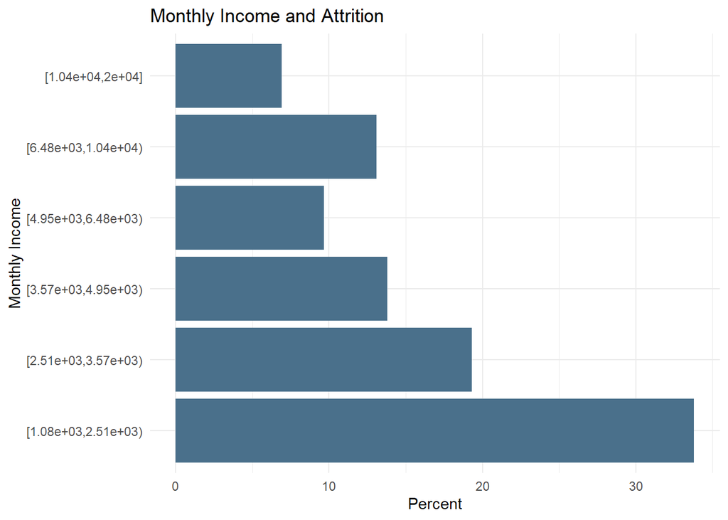

```r
join %>% ggplot(aes(x = monthly_income, y = perc)) + geom_bar(stat = 'identity', fill = 'skyblue4') + theme_minimal() + coord_flip() + ggtitle("Monthly Income and Attrition") + labs(x = "Monthly Income", y = "Percent")
```

```r
### external, not significant
total <- CStudy2_data %>% select(attrition, num_companies_worked) %>% group_by(num_companies_worked) %>% arrange(num_companies_worked) %>% count(num_companies_worked) %>% as.data.frame()

yes_count <- CStudy2_data %>% select(num_companies_worked, attrition) %>% group_by(num_companies_worked) %>% arrange(num_companies_worked) %>% filter(attrition == "1") %>% count(num_companies_worked) %>% rename(yes = n) %>% as.data.frame()

head(total)
```

```
##   num_companies_worked   n
## 1                    0 111
## 2                    1 320
## 3                    2  74
## 4                    3  91
## 5                    4  85
## 6                    5  43
```

```r
yes_count
```

```
##    num_companies_worked yes
## 1                     0  11
## 2                     1  60
## 3                     2   9
## 4                     3   9
## 5                     4   7
## 6                     5  11
## 7                     6   9
## 8                     7  11
## 9                     8   5
## 10                    9   8
```

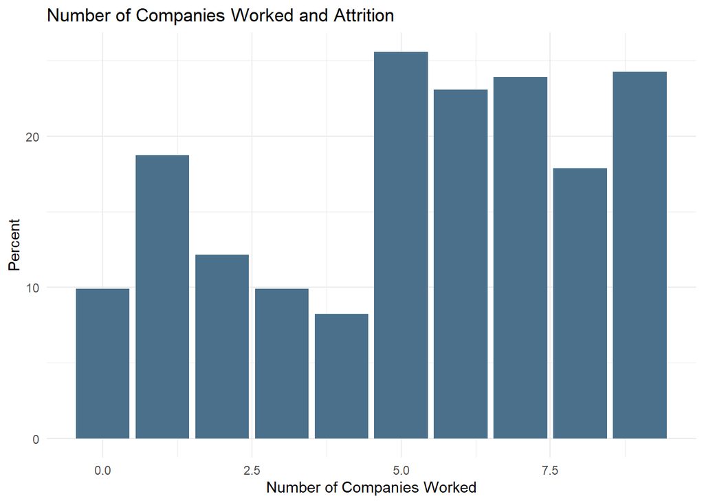

```r
join <- full_join(total, yes_count, by = "num_companies_worked")
join <- join %>% mutate(perc = (yes/n)*100)
join %>% ggplot(aes(x = num_companies_worked, y = perc)) + geom_bar(stat = 'identity', fill = 'skyblue4') + theme_minimal() + ggtitle("Number of Companies Worked and Attrition") + labs(x = "Number of Companies Worked", y = "Percent")
```

```r
### internal, significant
total <- CStudy2_data %>% select(attrition, over_time) %>% group_by(over_time) %>% arrange(over_time) %>% count(over_time) %>% as.data.frame()
yes_count <- CStudy2_data %>% select(over_time, attrition) %>% group_by(over_time) %>% arrange(over_time) %>% filter(attrition == "1") %>% count(over_time) %>% rename(yes = n) %>% as.data.frame()
head(total)
```

```
##   over_time   n
## 1        No 618
## 2       Yes 252
```

```r
yes_count
```

```
##   over_time yes
## 1        No  60
## 2       Yes  80
```

```r
join <- full_join(total, yes_count, by = "over_time")
join <- join %>% mutate(perc = (yes/n)*100)
join
```

```
##   over_time   n yes      perc
## 1        No 618  60  9.708738
## 2       Yes 252  80 31.746032
```

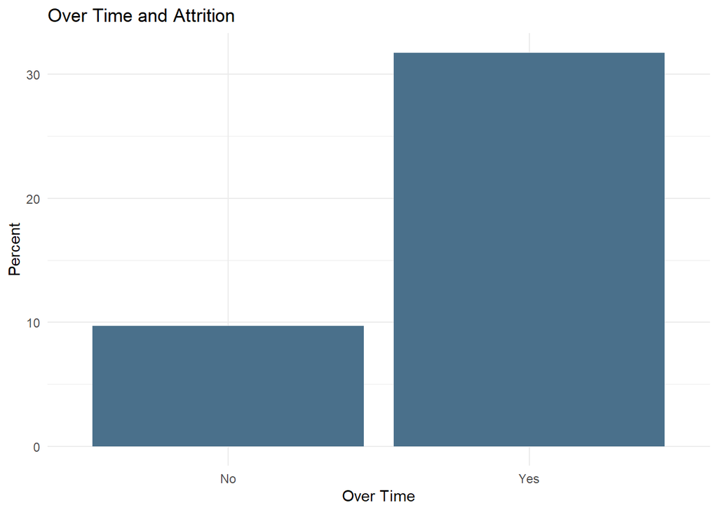

```r
join %>% ggplot(aes(x = over_time, y = perc)) + geom_bar(stat = 'identity', fill = 'skyblue4') + theme_minimal() + ggtitle("Over Time and Attrition") + labs(x = "Over Time", y = "Percent")
```

```r
### internal, significant
total <- CStudy2_data %>% select(attrition, percent_salary_hike) %>% group_by(percent_salary_hike) %>% arrange(percent_salary_hike) %>% count(percent_salary_hike) %>% as.data.frame()

yes_count <- CStudy2_data %>% select(percent_salary_hike, attrition) %>% group_by(percent_salary_hike) %>% arrange(percent_salary_hike) %>% filter(attrition == "1") %>% count(percent_salary_hike) %>% rename(yes = n) %>% as.data.frame()

head(total)
```

```
##   percent_salary_hike   n
## 1                  11 126
## 2                  12 119
## 3                  13 123
## 4                  14 120
## 5                  15  54
## 6                  16  43
```

```r
yes_count
```

```
##    percent_salary_hike yes
## 1                   11  24
## 2                   12  17
## 3                   13  21
## 4                   14  13
## 5                   15   8
## 6                   16  10
## 7                   17  10
## 8                   18   9
## 9                   19   5
## 10                  20   3
## 11                  21   2
## 12                  22   7
## 13                  23   5
## 14                  24   5
## 15                  25   1
```

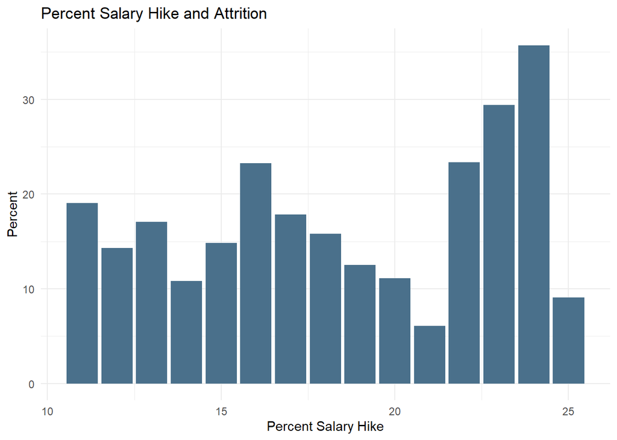

```r
join <- full_join(total, yes_count, by = "percent_salary_hike")
join <- join %>% mutate(perc = (yes/n)*100)
join %>% ggplot(aes(x = percent_salary_hike, y = perc)) + geom_bar(stat = 'identity',  fill = 'skyblue4') + theme_minimal() + ggtitle("Percent Salary Hike and Attrition") + labs(x = "Percent Salary Hike", y = "Percent")
```

```r
### internal, not significant
total <- CStudy2_data %>% select(attrition, performance_rating) %>% group_by(performance_rating) %>% arrange(performance_rating) %>% count(performance_rating) %>% as.data.frame()

yes_count <- CStudy2_data %>% select(performance_rating, attrition) %>% group_by(performance_rating) %>% arrange(performance_rating) %>% filter(attrition == "1") %>% count(performance_rating) %>% rename(yes = n) %>% as.data.frame()

head(total)
```

```
##   performance_rating   n
## 1                  3 738
## 2                  4 132
```

```r
yes_count
```

```
##   performance_rating yes
## 1                  3 117
## 2                  4  23
```

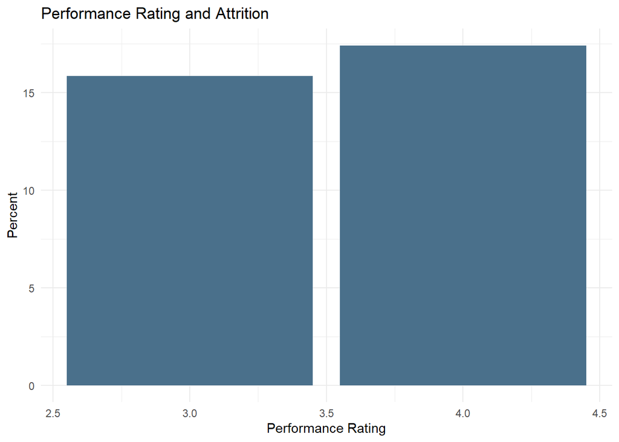

```r
join <- full_join(total, yes_count, by = "performance_rating")
join <- join %>% mutate(perc = (yes/n)*100)
join %>% ggplot(aes(x = performance_rating, y = perc)) + geom_bar(stat = 'identity', fill = 'skyblue4') +  theme_minimal() + ggtitle("Performance Rating and Attrition") + labs(x = "Performance Rating", y = "Percent")
```

```r
### external, not significant
total <- CStudy2_data %>% select(attrition, relationship_satisfaction) %>% group_by(relationship_satisfaction) %>% arrange(relationship_satisfaction) %>% count(relationship_satisfaction) %>% as.data.frame()

yes_count <- CStudy2_data %>% select(relationship_satisfaction, attrition) %>% group_by(relationship_satisfaction) %>% arrange(relationship_satisfaction) %>% filter(attrition == "1") %>% count(relationship_satisfaction) %>% rename(yes = n) %>% as.data.frame()

head(total)
```

```
##   relationship_satisfaction   n
## 1                         1 174
## 2                         2 171
## 3                         3 261
## 4                         4 264
```

```r
yes_count
```

```
##   relationship_satisfaction yes
## 1                         1  35
## 2                         2  27
## 3                         3  36
## 4                         4  42
```

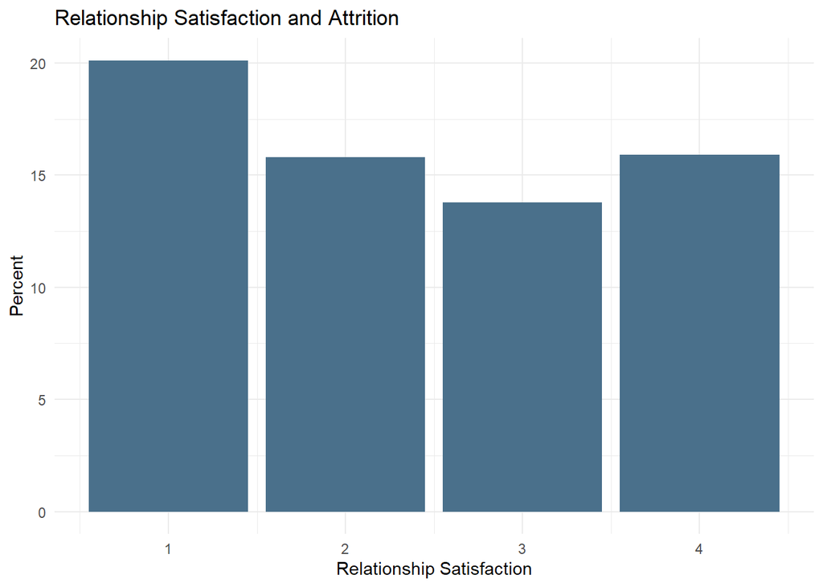

```r
join <- full_join(total, yes_count, by = "relationship_satisfaction")
join <- join %>% mutate(perc = (yes/n)*100)
join %>% ggplot(aes(x = relationship_satisfaction, y = perc)) + geom_bar(stat = 'identity', fill = 'skyblue4') + theme_minimal() + ggtitle("Relationship Satisfaction and Attrition") + labs(x = "Relationship Satisfaction", y = "Percent")
```

```r
### internal, not significant
total <- CStudy2_data %>% select(attrition, stock_option_level) %>% group_by(stock_option_level) %>% arrange(stock_option_level) %>% count(stock_option_level) %>% as.data.frame()

yes_count <- CStudy2_data %>% select(stock_option_level, attrition) %>% group_by(stock_option_level) %>% arrange(stock_option_level) %>% filter(attrition == "1") %>% count(stock_option_level) %>% rename(yes = n) %>% as.data.frame()

head(total)
```

```
##   stock_option_level   n
## 1                  0 379
## 2                  1 355
## 3                  2  81
## 4                  3  55
```

```r
yes_count
```

```
##   stock_option_level yes
## 1                  0  98
## 2                  1  27
## 3                  2   3
## 4                  3  12
```

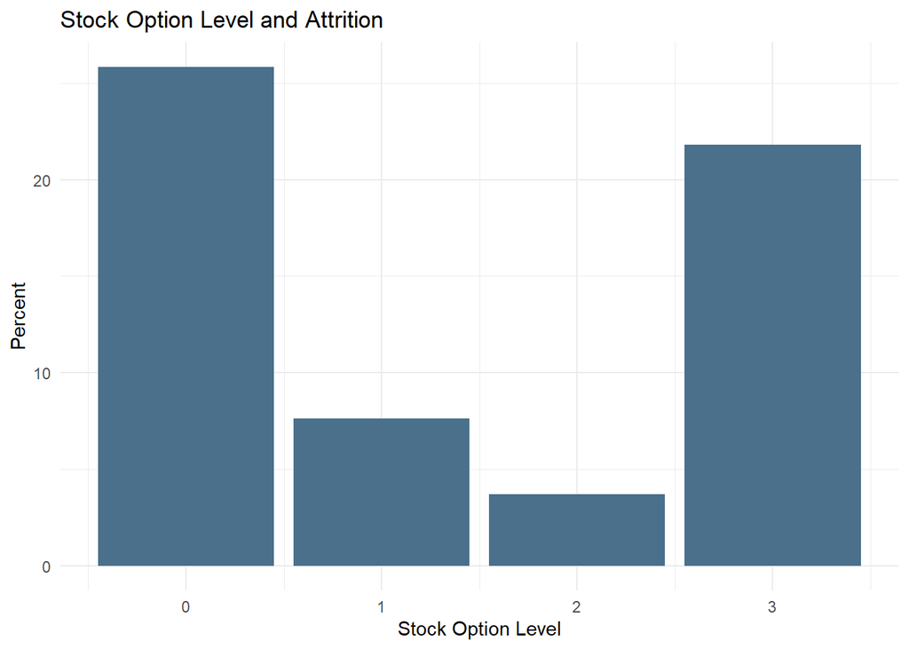

```r
join <- full_join(total, yes_count, by = "stock_option_level")
join <- join %>% mutate(perc = (yes/n)*100)
join %>% ggplot(aes(x = stock_option_level, y = perc)) + geom_bar(stat = 'identity', fill = 'skyblue4') + theme_minimal() + ggtitle("Stock Option Level and Attrition") + labs(x = "Stock Option Level", y = "Percent")
```

```r
### external, worth exploring
total <- CStudy2_data %>% select(attrition, total_working_years) %>% mutate(total_working_years = discretize(total_working_years, method = 'interval', breaks = 5)) %>% group_by(total_working_years) %>% arrange(total_working_years) %>% count(total_working_years) %>% as.data.frame()

yes_count <- CStudy2_data %>% select(total_working_years, attrition) %>% filter(attrition == "1") %>%
  mutate(total_working_years = discretize(total_working_years, method = 'interval', breaks = 5)) %>% group_by(total_working_years) %>% arrange(total_working_years) %>% filter(attrition == "1") %>% dplyr::count(total_working_years) %>% dplyr::rename(yes = n) %>% as.data.frame()

head(total)
```

```
##   total_working_years   n
## 1               [0,8) 305
## 2              [8,16) 370
## 3             [16,24) 129
## 4             [24,32)  47
## 5             [32,40]  19
```

```r
yes_count
```

```
##   total_working_years yes
## 1               [0,8)  79
## 2              [8,16)  42
## 3             [16,24)  13
## 4             [24,32)   4
## 5             [32,40]   2
```

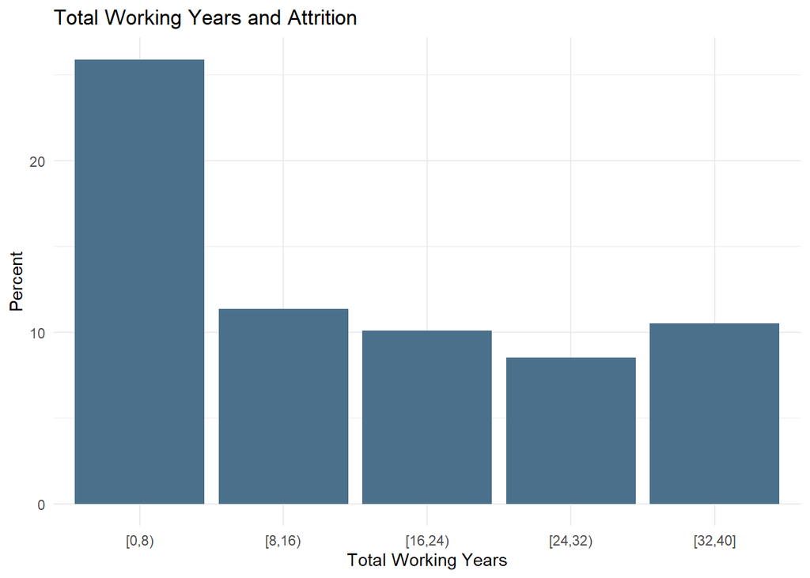

```r
join <- full_join(total, yes_count, by = "total_working_years")
join <- join %>% mutate(perc = (yes/n)*100)
join %>% ggplot(aes(x = total_working_years, y = perc)) + geom_bar(stat = 'identity', fill = 'skyblue4') + theme_minimal() + ggtitle("Total Working Years and Attrition") + labs(x = "Total Working Years", y = "Percent")
```

```r
### internal?, not significant
total <- CStudy2_data %>% select(attrition, training_times_last_year) %>% group_by(training_times_last_year) %>% arrange(training_times_last_year) %>% count(training_times_last_year) %>% as.data.frame()

yes_count <- CStudy2_data %>% select(training_times_last_year, attrition) %>% group_by(training_times_last_year) %>% arrange(training_times_last_year) %>% filter(attrition == "1") %>% count(training_times_last_year) %>% rename(yes = n) %>% as.data.frame()

head(total)
```

```
##   training_times_last_year   n
## 1                        0  30
## 2                        1  39
## 3                        2 309
## 4                        3 308
## 5                        4  73
## 6                        5  75
```

```r
yes_count
```

```
##   training_times_last_year yes
## 1                        0   8
## 2                        1   5
## 3                        2  57
## 4                        3  43
## 5                        4  16
## 6                        5   7
## 7                        6   4
```

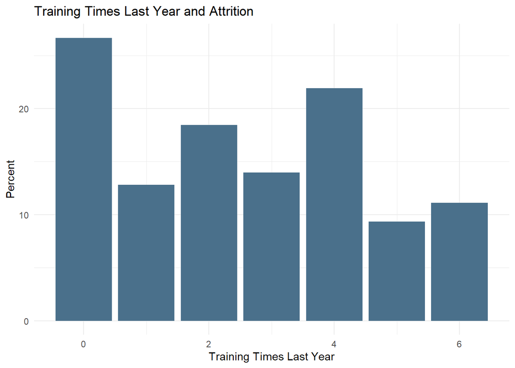

```r
join <- full_join(total, yes_count, by = "training_times_last_year")
join <- join %>% mutate(perc = (yes/n)*100)
join %>% ggplot(aes(x = training_times_last_year, y = perc)) + geom_bar(stat = 'identity', fill = 'skyblue4') + theme_minimal() + ggtitle("Training Times Last Year and Attrition") + labs(x = "Training Times Last Year", y = "Percent")
```

```r
### internal/external, significant
total <- CStudy2_data %>% select(attrition, work_life_balance) %>% group_by(work_life_balance) %>% arrange(work_life_balance) %>% count(work_life_balance) %>% as.data.frame()

yes_count <- CStudy2_data %>% select(work_life_balance, attrition) %>% group_by(work_life_balance) %>% arrange(work_life_balance) %>% filter(attrition == "1") %>% count(work_life_balance) %>% rename(yes = n) %>% as.data.frame()

head(total)
```

```
##   work_life_balance   n
## 1                 1  48
## 2                 2 192
## 3                 3 532
## 4                 4  98
```

```r
yes_count
```

```
##   work_life_balance yes
## 1                 1  17
## 2                 2  30
## 3                 3  80
## 4                 4  13
```

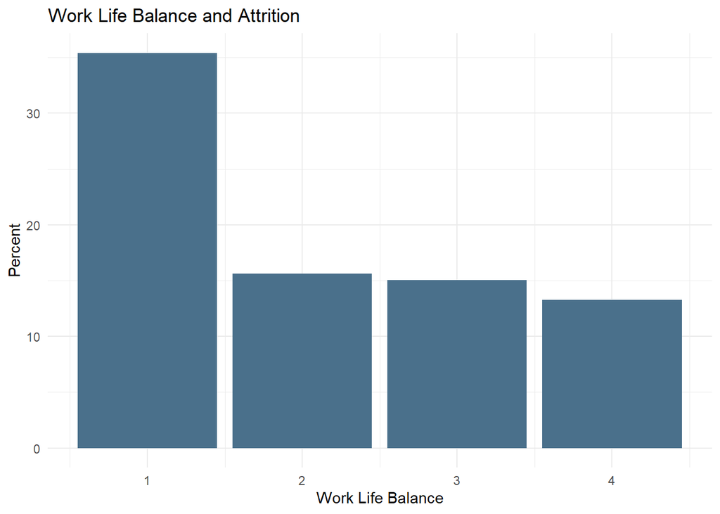

```r
join <- full_join(total, yes_count, by = "work_life_balance")
join <- join %>% mutate(perc = (yes/n)*100)
join %>% ggplot(aes(x = work_life_balance, y = perc)) + geom_bar(stat = 'identity', fill = 'skyblue4') + theme_minimal() + ggtitle("Work Life Balance and Attrition") + labs(x = "Work Life Balance", y = "Percent")
```

```r
### external, not significant
total <- CStudy2_data %>% select(attrition, years_at_company) %>% mutate(years_at_company = discretize(years_at_company, method = 'interval', breaks = 4)) %>% group_by(years_at_company) %>% arrange(years_at_company) %>% count(years_at_company) %>% as.data.frame()

yes_count <- CStudy2_data %>% select(years_at_company, attrition) %>% mutate(years_at_company = discretize(years_at_company, method = 'interval', breaks = 4)) %>% filter(attrition == "1") %>% group_by(years_at_company) %>% arrange(years_at_company) %>% count(years_at_company) %>% rename(yes = n) %>% as.data.frame()

head(total)
```

```
##   years_at_company   n
## 1           [0,10) 644
## 2          [10,20) 175
## 3          [20,30)  42
## 4          [30,40]   9
```

```r
yes_count
```

```
##   years_at_company yes
## 1           [0,10) 114
## 2          [10,20)  21
## 3          [20,30)   3
## 4          [30,40]   2
```

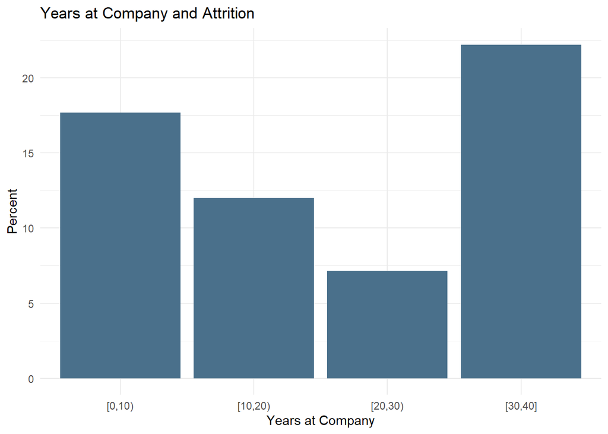

```r
join <- full_join(total, yes_count, by = "years_at_company")
join <- join %>% mutate(perc = (yes/n)*100)
join %>% ggplot(aes(x = years_at_company, y = perc)) + geom_bar(stat = 'identity', fill = 'skyblue4') + theme_minimal() + ggtitle("Years at Company and Attrition") + labs(x = "Years at Company", y = "Percent")
```

```r
### external, not significant
total <- CStudy2_data %>% select(attrition, years_in_current_role) %>% mutate(years_in_current_role = discretize(years_in_current_role, method = 'interval', breaks = 6)) %>% group_by(years_in_current_role) %>% arrange(years_in_current_role) %>% count(years_in_current_role) %>% as.data.frame()

yes_count <- CStudy2_data %>% select(years_in_current_role, attrition) %>% mutate(years_in_current_role = discretize(years_in_current_role, method = 'interval', breaks = 6)) %>% filter(attrition == "1") %>% group_by(years_in_current_role) %>% arrange(years_in_current_role) %>% count(years_in_current_role) %>% rename(yes = n) %>% as.data.frame()

head(total)
```

```
##   years_in_current_role   n
## 1                 [0,3) 412
## 2                 [3,6) 147
## 3                 [6,9) 209
## 4                [9,12)  69
## 5               [12,15)  23
## 6               [15,18]  10
```

```r
yes_count
```

```
##   years_in_current_role yes
## 1                 [0,3)  93
## 2                 [3,6)  15
## 3                 [6,9)  23
## 4                [9,12)   5
## 5               [12,15)   3
## 6               [15,18]   1
```

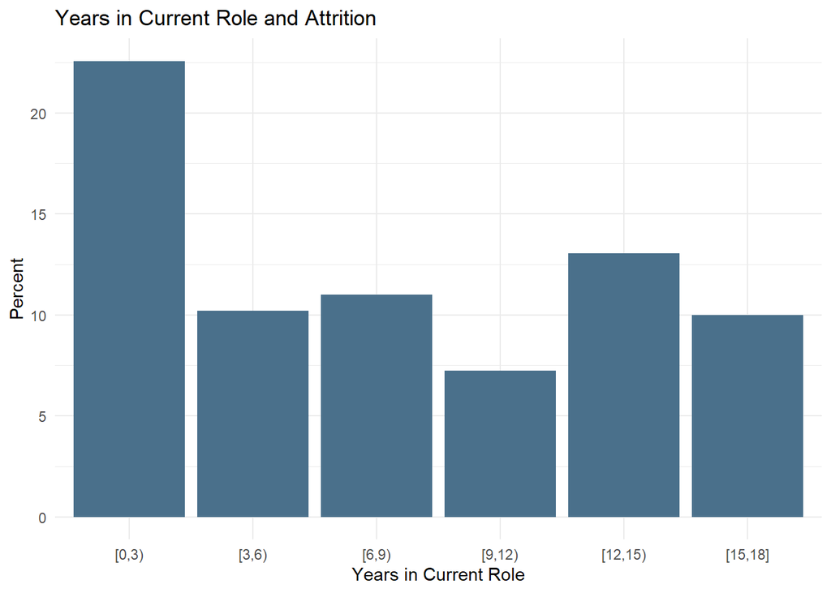

```r
join <- full_join(total, yes_count, by = "years_in_current_role")
join <- join %>% mutate(perc = (yes/n)*100)
join %>% ggplot(aes(x = years_in_current_role, y = perc)) + geom_bar(stat = 'identity', fill =  'skyblue4') + theme_minimal() + ggtitle("Years in Current Role and Attrition") + labs(x = "Years in Current Role", y = "Percent")
```

```r
### internal, not significant
total <- CStudy2_data %>% select(attrition, years_since_last_promotion) %>% mutate(years_since_last_promotion = discretize(years_since_last_promotion, method = 'interval', breaks = 5)) %>% group_by(years_since_last_promotion) %>% arrange(years_since_last_promotion) %>% count(years_since_last_promotion) %>% as.data.frame()

yes_count <- CStudy2_data %>% select(years_since_last_promotion, attrition) %>% mutate(years_since_last_promotion = discretize(years_since_last_promotion, method = 'interval', breaks = 5)) %>% filter(attrition == "1") %>% group_by(years_since_last_promotion) %>% arrange(years_since_last_promotion) %>% count(years_since_last_promotion) %>% rename(yes = n) %>% as.data.frame()

head(total)
```

```
##   years_since_last_promotion   n
## 1                      [0,3) 650
## 2                      [3,6)  94
## 3                      [6,9)  76
## 4                     [9,12)  27
## 5                    [12,15]  23
```

```r
yes_count
```

```
##   years_since_last_promotion yes
## 1                      [0,3) 108
## 2                      [3,6)   9
## 3                      [6,9)  13
## 4                     [9,12)   6
## 5                    [12,15]   4
```

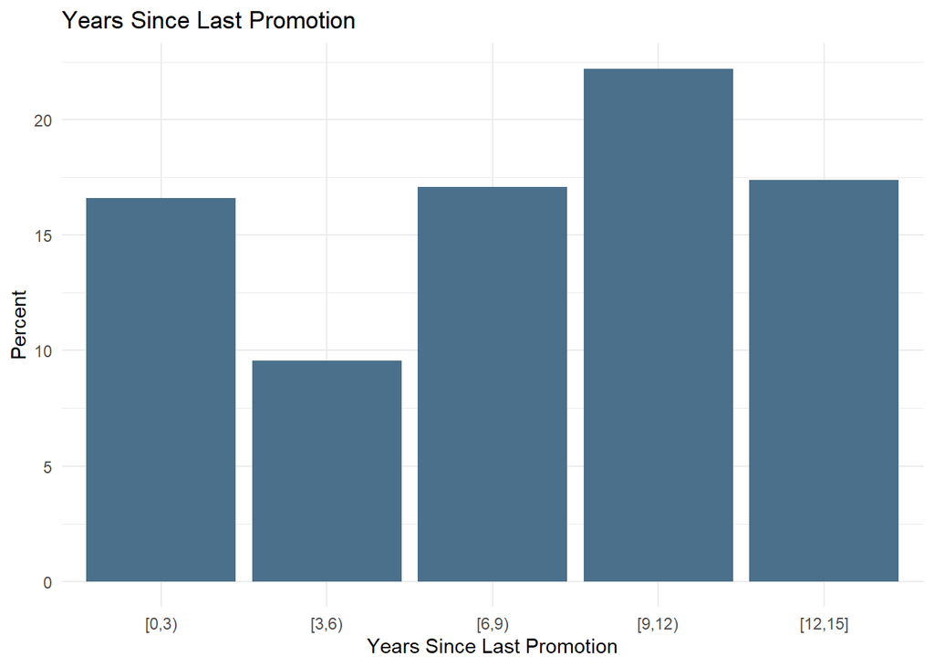

```r
join <- full_join(total, yes_count, by = "years_since_last_promotion")
join <- join %>% mutate(perc = (yes/n)*100)
join %>% ggplot(aes(x = years_since_last_promotion, y = perc)) + geom_bar(stat = 'identity', fill = 'skyblue4') + theme_minimal() + ggtitle("Years Since Last Promotion") + labs(x = "Years Since Last Promotion", y = "Percent")
```

```r
### internal, not significant
total <- CStudy2_data %>% select(attrition, years_with_curr_manager) %>%
  mutate(years_with_curr_manager = discretize(years_with_curr_manager, method = 'interval', breaks = 5)) %>%
  group_by(years_with_curr_manager) %>% arrange(years_with_curr_manager) %>% count(years_with_curr_manager) %>% as.data.frame()
yes_count <- CStudy2_data %>% select(years_with_curr_manager, attrition) %>%
  mutate(years_with_curr_manager = discretize(years_with_curr_manager, method = 'interval', breaks = 5)) %>%
  filter(attrition == "1") %>% group_by(years_with_curr_manager) %>% arrange(years_with_curr_manager) %>%
  count(years_with_curr_manager) %>% rename(yes = n) %>% as.data.frame()
head(total)
```

```
##   years_with_curr_manager   n
## 1                 [0,3.4) 484
## 2               [3.4,6.8)  85
## 3              [6.8,10.2) 261
## 4             [10.2,13.6)  31
## 5               [13.6,17]   9
```

```r
yes_count
```

```
##   years_with_curr_manager yes
## 1                 [0,3.4)  95
## 2               [3.4,6.8)  11
## 3              [6.8,10.2)  32
## 4             [10.2,13.6)   1
## 5               [13.6,17]   1
```

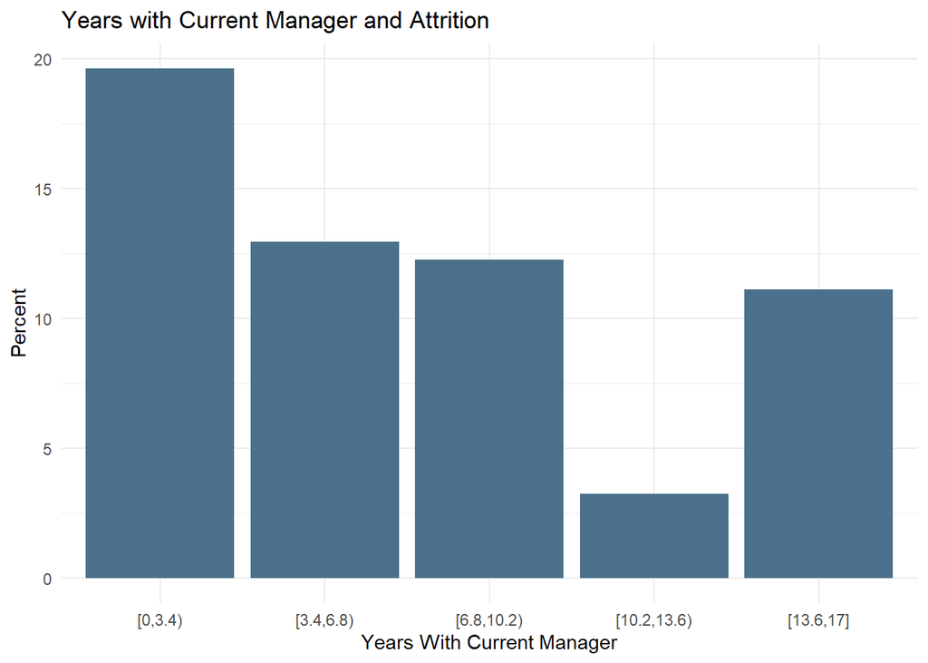

```r
join <- full_join(total, yes_count, by = "years_with_curr_manager")
join <- join %>% mutate(perc = (yes/n)*100)
join %>% ggplot(aes(x = years_with_curr_manager, y = perc)) + geom_bar(stat = 'identity', fill = 'skyblue4') + theme_minimal() + ggtitle("Years with Current Manager and Attrition") + labs(x = "Years With Current Manager", y = "Percent")
```

## I. Top Factors Contributing to Attrition

### Significance:

#### Setting significance at >30% of attrition in at least one level (if factor)

### Internal

#### - Work Life Balance

#### - Percent Salary Hike

#### - Overtime

#### - Income

#### - Job Involvement

### Worth Exploring:

#### - Job Satisfaction

#### - Job Role

### External

#### - Work Life Balance

#### - Distance from Home

#### - Age

### Worth Exploring:

#### - Total Working Years

### Model Comparison:

#### Used regression modeling to examine those variables using AIC model selection to choose top 3 contributors to attrition.

#### Made all combinations and interactions for 3 variables to predict attrition

```r
perc_sal_hike.mod <- glm(attrition ~ percent_salary_hike, data = CStudy2_data, family = 'binomial')
over_time.mod <- glm(attrition ~ factor(over_time), data = CStudy2_data, family = 'binomial')
monthly_inc.mod <- glm(attrition ~ monthly_income, data = CStudy2_data, family = 'binomial')
job_inv.mod <- glm(attrition ~ factor(job_involvement), data = CStudy2_data, family = 'binomial')
wlb.mod <- glm(attrition ~ factor(work_life_balance), data = CStudy2_data, family = 'binomial')
psh.ot.mod <- glm(attrition ~ percent_salary_hike +  factor(over_time), data = CStudy2_data, family = 'binomial')
psh.mi.mod <- glm(attrition ~ percent_salary_hike +  monthly_income, data = CStudy2_data, family = 'binomial')
psh.ji.mod <- glm(attrition ~ percent_salary_hike +  factor(job_involvement), data = CStudy2_data, family = 'binomial')
psh.wlb.mod <- psh.ot.mod <- glm(attrition ~ percent_salary_hike + factor(work_life_balance), data = CStudy2_data, family = 'binomial')
ot.mi.mod <- glm(attrition ~ factor(over_time) + monthly_income, data = CStudy2_data, family = 'binomial')
ot.ji.mod <- glm(attrition ~ factor(over_time) + factor(job_involvement), data = CStudy2_data, family = 'binomial')
ot.wlb.mod <- glm(attrition ~ factor(over_time) + factor(work_life_balance), data = CStudy2_data, family = 'binomial')
mi.ji.mod <- glm(attrition ~ monthly_income + factor(job_involvement), data = CStudy2_data, family = 'binomial')
mi.wlb.mod <- glm(attrition ~ monthly_income + factor(work_life_balance), data = CStudy2_data, family = 'binomial')
ji.wlb.mod <- glm(attrition ~ factor(job_involvement) + factor(work_life_balance), data = CStudy2_data, family = 'binomial')
mi.ot.int.mod <- glm(attrition ~ factor(over_time)*monthly_income, data = CStudy2_data, family = 'binomial')
mi.ji.int.mod <- glm(attrition ~ factor(over_time)*factor(job_involvement), data = CStudy2_data, family = 'binomial')
mi.wlb.int.mod <- glm(attrition ~ monthly_income*factor(work_life_balance), data = CStudy2_data, family = 'binomial')
ot.ji.wlb.mod <- glm(attrition ~ factor(over_time) + factor(job_involvement) + factor(work_life_balance), data = CStudy2_data, family = 'binomial')
ot.ji.wlb.int.mod <- glm(attrition ~ factor(over_time) + factor(job_involvement)*factor(work_life_balance), data = CStudy2_data, family = 'binomial')
ot.wlb.int.ji.mod <- glm(attrition ~ factor(over_time)*factor(work_life_balance) + factor(job_involvement), data = CStudy2_data, family = 'binomial')
ot.ji.mi.mod <- glm(attrition ~ factor(over_time) + factor(job_involvement) + monthly_income, data = CStudy2_data, family = 'binomial')
ot.ji.mi.int.mod <- glm(attrition ~ factor(over_time) + factor(job_involvement)*monthly_income, data = CStudy2_data, family = 'binomial')
ot.ji.int.mi.mod <- glm(attrition ~ factor(over_time)*factor(job_involvement) + monthly_income, data = CStudy2_data, family = 'binomial')


models <- list(over_time.mod, monthly_inc.mod, job_inv.mod, wlb.mod, psh.ji.mod, ot.mi.mod, ot.ji.mod, ot.wlb.mod, mi.ji.mod, mi.wlb.mod, ji.wlb.mod, mi.ot.int.mod, mi.ji.int.mod, mi.wlb.int.mod, ot.ji.wlb.mod, ot.ji.wlb.int.mod, ot.wlb.int.ji.mod, ot.ji.mi.mod, ot.ji.mi.int.mod, ot.ji.int.mi.mod)
model.names <- c('over_time.mod', 'monthly_inc.mod', 'job_inv.mod', 'wlb.mod', 'psh.ji.mod', 'ot.mi.mod', 'ot.ji.mod', 'ot.wlb.mod', 'mi.ji.mod', 'mi.wlb.mod', 'ji.wlb.mod', 'mi.ot.int.mod', 'mi.ji.int.mod', 'mi.wlb.int.mod', 'ot.ji.wlb.mod', 'ot.ji.wlb.int.mod', 'ot.wlb.int.ji.mod', 'ot.ji.mi.mod', 'ot.ji.mi.int.mod', 'ot.ji.int.mi.mod')
aictab(cand.set = models, modnames = model.names)
```

```
##
## Model selection based on AICc:
##
##                    K   AICc Delta_AICc AICcWt Cum.Wt      LL
## ot.ji.mi.mod       6 663.90       0.00   0.69   0.69 -325.90
## ot.ji.mi.int.mod   9 666.01       2.11   0.24   0.93 -323.90
## ot.ji.int.mi.mod   9 668.44       4.54   0.07   1.00 -325.11
## ot.ji.wlb.mod      8 680.60      16.70   0.00   1.00 -332.22
## ot.wlb.int.ji.mod 11 685.47      21.57   0.00   1.00 -331.58
## ot.ji.mod          5 687.15      23.25   0.00   1.00 -338.54
## mi.ot.int.mod      4 689.08      25.18   0.00   1.00 -340.52
## ot.mi.mod          3 689.56      25.66   0.00   1.00 -341.77
## ot.ji.wlb.int.mod 17 691.04      27.14   0.00   1.00 -328.16
## mi.ji.int.mod      8 691.62      27.72   0.00   1.00 -337.73
## ot.wlb.mod         5 706.19      42.29   0.00   1.00 -348.06
## over_time.mod      2 712.82      48.92   0.00   1.00 -354.40
## mi.ji.mod          5 718.54      54.64   0.00   1.00 -354.24
## ji.wlb.mod         7 736.70      72.80   0.00   1.00 -361.29
## mi.wlb.mod         5 741.24      77.34   0.00   1.00 -365.59
## job_inv.mod        4 742.23      78.33   0.00   1.00 -367.09
## mi.wlb.int.mod     8 742.68      78.78   0.00   1.00 -363.26
## psh.ji.mod         5 744.01      80.10   0.00   1.00 -366.97
## monthly_inc.mod    2 746.55      82.65   0.00   1.00 -371.27
## wlb.mod            4 764.04     100.14   0.00   1.00 -378.00
```

## II. Predicting Attrition

### Building NB model

#### We created a training set to build our model and a validation set that we will use in the end to judge our model.

```r
set.seed(3)

#I will create a for loop to evaluate or model across 300 iterations
iterations = 300
masterAcc = matrix(nrow = iterations)
masterSens = matrix(nrow = iterations)
masterSpec = matrix(nrow = iterations)
splitPerc=.75

for(j in 1:iterations)
{
  trainIndices = sample(1:dim(CStudy2_data)[1],round(splitPerc*dim(CStudy2_data)[1]))
  train1 = CStudy2_data[trainIndices,]
  test1 = CStudy2_data[-trainIndices,]

  model = naiveBayes(attrition ~
                       age+
                       environment_satisfaction+
                       job_satisfaction+
                       distance_from_home+
                       education_field+
                       hourly_rate+
                       job_involvement+
                       job_level+
                       job_role+
                       marital_status+
                       monthly_income+
                       num_companies_worked+
                       over_time+
                       stock_option_level+
                       total_working_years+
                       training_times_last_year+
                       work_life_balance+
                       years_at_company+
                       years_in_current_role+
                       years_with_curr_manager, data = train1)
  classifications = predict(model, test1)
  actual = test1$attrition
  CM = confusionMatrix(table(classifications,actual))
  masterAcc[j] = CM$overall[1]
  masterSens[j] = CM$byClass[1]
  masterSpec[j] = CM$byClass[2]
}

MeanAcc = colMeans(masterAcc)
MeanSens = colMeans(masterSens)
MeanSpec = colMeans(masterSpec)

MeanAcc
```

```
## [1] 0.8070795
```

```r
MeanSens
```

```
## [1] 0.8459928
```

```r
MeanSpec
```

```
## [1] 0.6062724
```

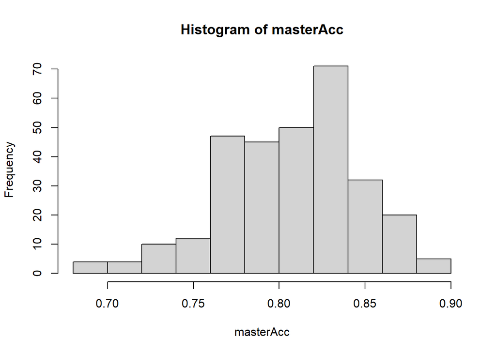

```r
hist(masterAcc)
```

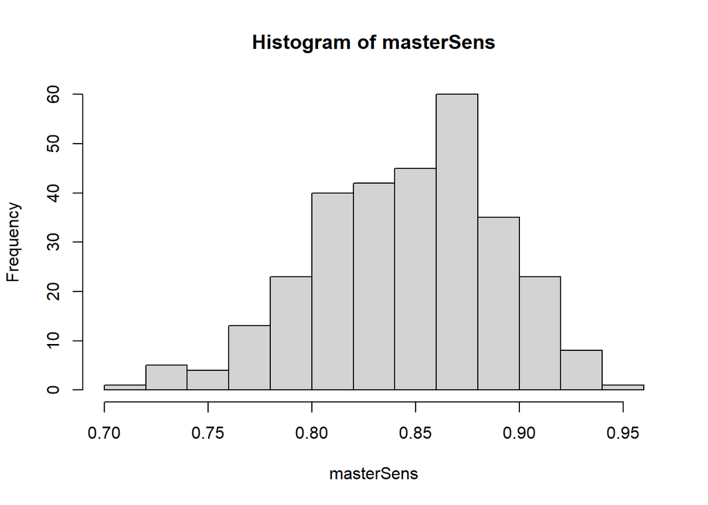

```r
hist(masterSens)
```

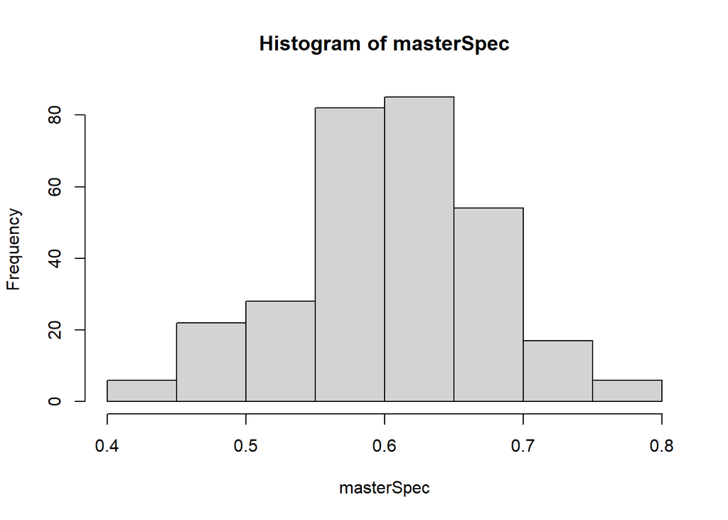

```r
hist(masterSpec)
```

```r
sum(masterSpec > 0.6)
```

```
## [1] 162
```

#### Our model predicting attrition has a mean accuracy of 80.7%, mean sensitivity of 84.6% and mean specificity of 60.63%.

## III. Job Role Insights

#### In this next part, I’ll examine job role specific trends.

#### First, I wanted to investigate if there’s any disparity with respect to job satisfaction throughout job roles

```r
### job satisfaction by role
js <- CStudy2_data %>% select(job_role, job_satisfaction) %>% group_by(job_role) %>% mutate(job_role = factor(job_role)) %>% summarize(mean(job_satisfaction)) %>% as.data.frame() %>% rename(average_job_satisfaction = 'mean(job_satisfaction)')
js
```

```
##                    job_role average_job_satisfaction
## 1 healthcare_representative                 2.828947
## 2           human_resources                 2.555556
## 3     laboratory_technician                 2.686275
## 4                   manager                 2.509804
## 5    manufacturing_director                 2.724138
## 6         research_director                 2.490196
## 7        research_scientist                 2.802326
## 8           sales_executive                 2.725000
## 9      sales_representative                 2.698113
```

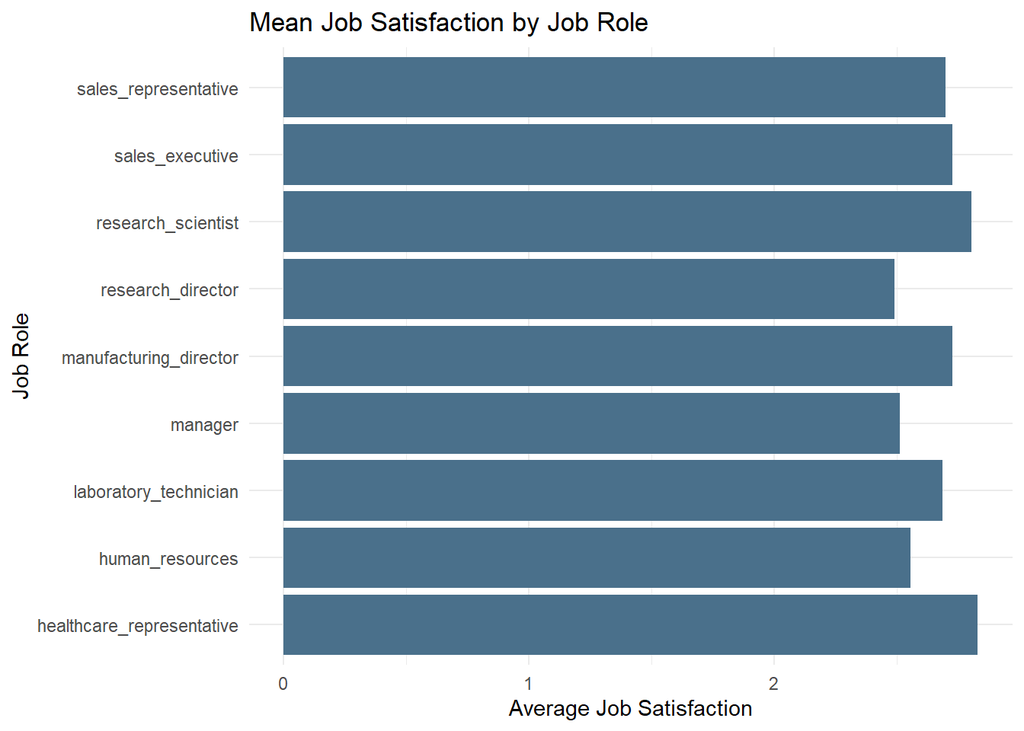

```r
js %>% ggplot(aes(x = job_role, y = average_job_satisfaction)) + geom_bar(stat = 'identity', fill = 'skyblue4') + coord_flip() + theme_minimal() + ggtitle("Mean Job Satisfaction by Job Role") + labs(x = "Job Role", y  = "Average Job Satisfaction")
```

### Analysis:

#### Through visual inspection from the graph above, there doesn’t appear to be a noticeable difference in job satisfaction by job role. Notwithstanding, healthcare representatives had the highest average job satisfaction with 2.83 and research director had the lowest with 2.49. Although there wasn’t a notable difference between job roles, it is always recommendable to increase average job satisfaction across all job roles.